# Machine Learning 2019: Tree-Based Methods

Peter Stella

10/28/2019

## Tree-Based Methods

Decision tree is a type of supervised learning algorithm that can be used in both regression and classification problems. Tree-based methods works for both categorical and continuous input and output variables.

```r
data("Carseats")
carseats = Carseats
head(carseats)
```

```
##   Sales CompPrice Income Advertising Population Price ShelveLoc Age
## 1  9.50       138     73          11        276   120       Bad  42
## 2 11.22       111     48          16        260    83      Good  65
## 3 10.06       113     35          10        269    80    Medium  59
## 4  7.40       117    100           4        466    97    Medium  55
## 5  4.15       141     64           3        340   128       Bad  38
## 6 10.81       124    113          13        501    72       Bad  78
##   Education Urban  US
## 1        17   Yes Yes
## 2        10   Yes Yes
## 3        12   Yes Yes
## 4        14   Yes Yes
## 5        13   Yes  No
## 6        16    No Yes
```

```r
#convert quantitative variable Sales into a binary response
High = ifelse(carseats$Sales<=8, "No", "Yes")
carseats = data.frame(carseats, High)

head(carseats)
```

```
##   Sales CompPrice Income Advertising Population Price ShelveLoc Age
## 1  9.50       138     73          11        276   120       Bad  42
## 2 11.22       111     48          16        260    83      Good  65
## 3 10.06       113     35          10        269    80    Medium  59
## 4  7.40       117    100           4        466    97    Medium  55
## 5  4.15       141     64           3        340   128       Bad  38
## 6 10.81       124    113          13        501    72       Bad  78
##   Education Urban  US High
## 1        17   Yes Yes  Yes
## 2        10   Yes Yes  Yes
## 3        12   Yes Yes  Yes
## 4        14   Yes Yes   No
## 5        13   Yes  No   No
## 6        16    No Yes  Yes
```

## Bagging: Random Forest

Bagging involves creating multiple copies of the original training dataset using the bootstrap, fitting a separate decision tree to each copy, and then combining all of the trees in order to create a single predictive model. Each tree is built on a bootstrapped dataset, independent of the other trees.

Random Forest: Each time a split in a tree is considered, a random sample of m predictors is chosen as split candidates from the full set of p predictors. The split is allowed to use only one of those m predictors.

## Boosting

Boosting is another approach to improve the predictions resulting from a decision tree. Trees are grown sequentially: each tree is grown using information from previously grown trees. Each tree is fitted on a modified version of the original dataset.

## Homework

1. Attempt a regression tree-based method (not covered in this tutorial) on a reasonable dataset of your choice. Explain the results.

Repeating the above carseat example, but with a continues dependent variable (sales)

```r
#set seed to make results reproducible
set.seed(1)

#split data into train and test subset (250 and 150 respectively)
traincar <- sample(1:nrow(carseats), 250)

#Fit train subset of data to model
treecar <- tree(Sales~., Carseats, subset = traincar)
summary(treecar)
```

```
##
## Regression tree:
## tree(formula = Sales ~ ., data = Carseats, subset = traincar)
## Variables actually used in tree construction:
## [1] "ShelveLoc"   "Price"       "Age"         "Income"      "Advertising"
## [6] "CompPrice"
## Number of terminal nodes:  18
## Residual mean deviance:  2.373 = 550.5 / 232
## Distribution of residuals:
##     Min.  1st Qu.   Median     Mean  3rd Qu.     Max.
## -4.21900 -0.85350  0.01864  0.00000  0.94390  4.43400
```

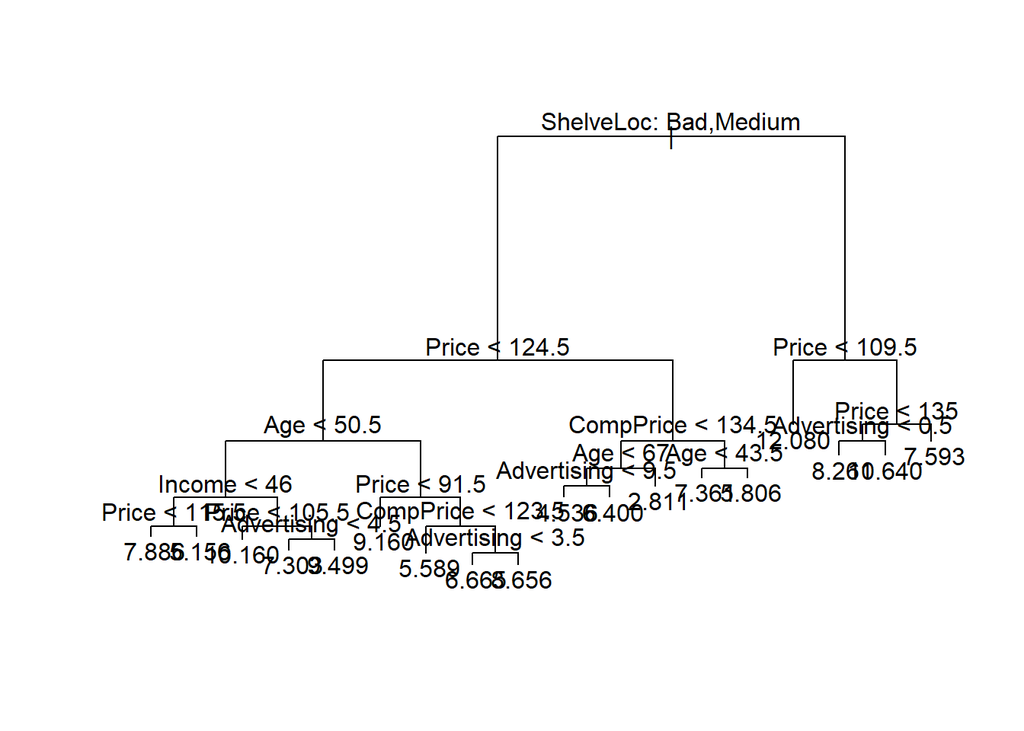

```r
plot(treecar)
text(treecar, pretty=0)
```

```r
carpred <-  predict(treecar, Carseats[-traincar,])
```

```r
cartest <- Carseats[-traincar,]
cartest <- cartest$Sales
cartest <- data.frame(carpred, cartest)
```

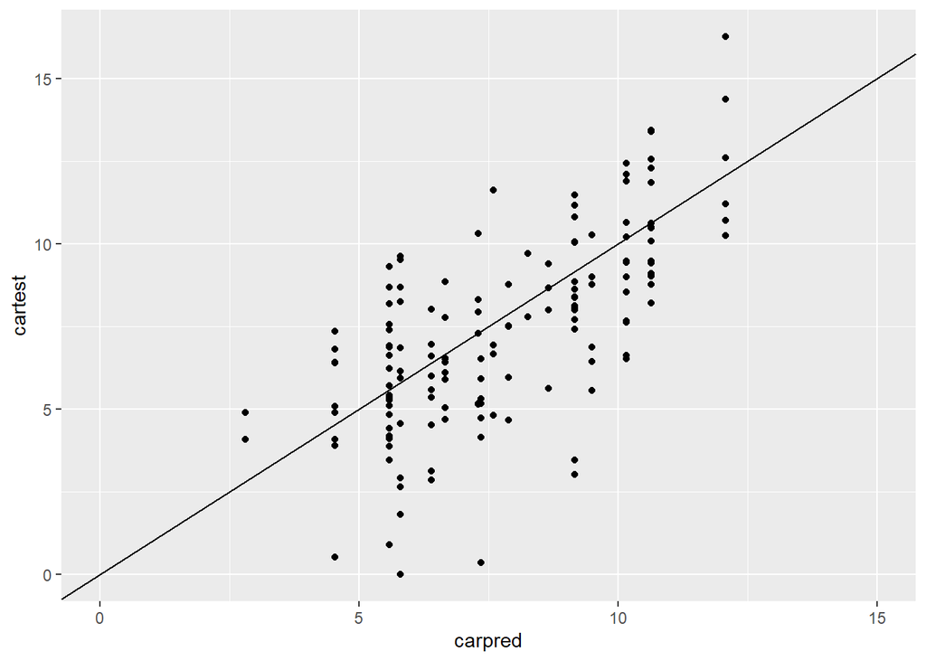

```r
ggplot(data=cartest, aes(x=carpred, y=cartest))+
geom_point()+ geom_abline()+xlim(0,15)
```

2. Attempt both a bagging and boosting method on a reasonable dataset of your choice. Explain the results.

```r
data("PimaIndiansDiabetes")
```

```r
str(PimaIndiansDiabetes)
```

```
## 'data.frame':    768 obs. of  9 variables:
##  $ pregnant: num  6 1 8 1 0 5 3 10 2 8 ...
##  $ glucose : num  148 85 183 89 137 116 78 115 197 125 ...
##  $ pressure: num  72 66 64 66 40 74 50 0 70 96 ...
##  $ triceps : num  35 29 0 23 35 0 32 0 45 0 ...
##  $ insulin : num  0 0 0 94 168 0 88 0 543 0 ...
##  $ mass    : num  33.6 26.6 23.3 28.1 43.1 25.6 31 35.3 30.5 0 ...
##  $ pedigree: num  0.627 0.351 0.672 0.167 2.288 ...
##  $ age     : num  50 31 32 21 33 30 26 29 53 54 ...
##  $ diabetes: Factor w/ 2 levels "neg","pos": 2 1 2 1 2 1 2 1 2 2 ...
```

```r
pima <- PimaIndiansDiabetes %>% mutate(diabetes=ifelse(diabetes=="pos",1,0))
pnumtrain = sample(1:nrow(PimaIndiansDiabetes), 600)
```

```r
ptrain = sample(1:nrow(PimaIndiansDiabetes), 600)

#fit training subset of data to model
rfpima = randomForest(diabetes~., data = PimaIndiansDiabetes, subset = ptrain)
rfpima
```

```
##
## Call:
##  randomForest(formula = diabetes ~ ., data = PimaIndiansDiabetes,      subset = ptrain)
##                Type of random forest: classification
##                      Number of trees: 500
## No. of variables tried at each split: 2
##
##         OOB estimate of  error rate: 21.5%
## Confusion matrix:
##     neg pos class.error
## neg 347  45   0.1147959
## pos  84 124   0.4038462
```

```r
poob.err = double(8)
ptest.err = double(8)

#In a loop of mtry from 1 to 8, you first fit the randomForest to the train dataset
for(mtry in 1:8){
  pfit = randomForest(diabetes~., data = PimaIndiansDiabetes, subset = ptrain, mtry=mtry, ntree = 350)
  poob.err[mtry] = pfit$err.rate[350] ##extract error rate
  ppred = predict(pfit, PimaIndiansDiabetes[-ptrain,]) #predict on test dataset
  ptest.err[mtry] = with(PimaIndiansDiabetes[-ptrain,], (1-mean(ppred==diabetes))) #compute test error
}
```

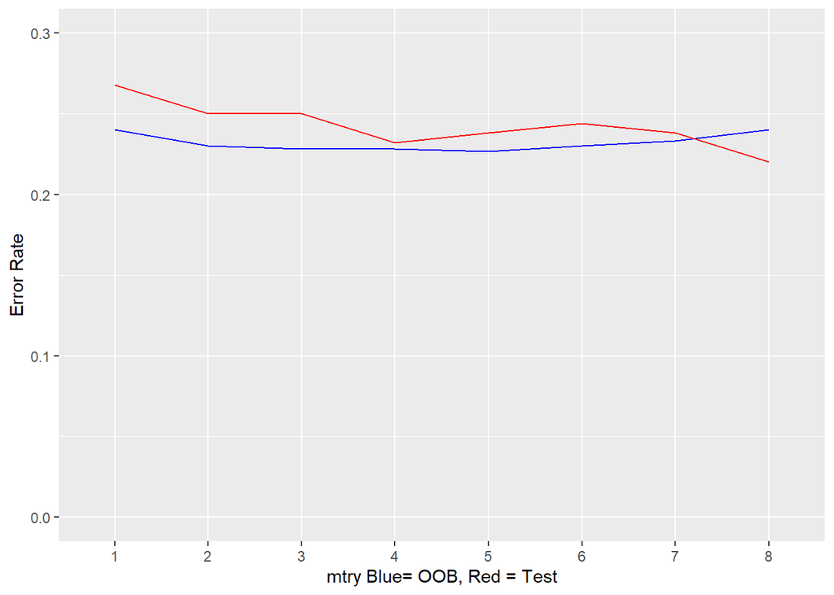

```r
pplot <- data.frame(poob.err,ptest.err) %>% add_rownames()
ggplot()+
geom_line(data=pplot, aes(x=rowname, y=poob.err) ,color="blue", group=1)+
geom_line(data=pplot, aes(x=rowname, y=ptest.err), color="red",group=1)+
ylim(0,0.3)+
xlab("mtry Blue= OOB, Red = Test")+
ylab("Error Rate")
```

OOB error drops slightly with increased number of variables use for splitting up to 4/5, while test error remains basically stable, with an unexpected drop at 8, which I cannot explain well. Admittedly, I am using a very primitive expression of error (misclassification rate), rather than a more complex one such as AUC.

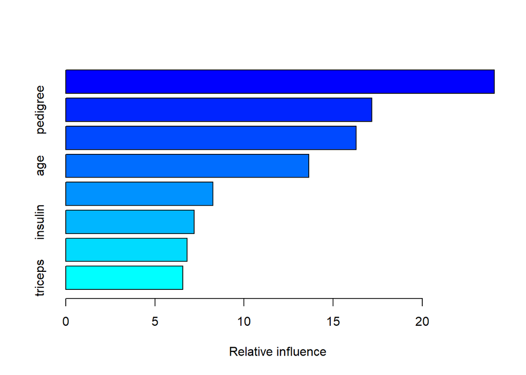

```
##               var   rel.inf
## glucose   glucose 24.036671
## pedigree pedigree 17.178243
## mass         mass 16.298893
## age           age 13.642863
## pressure pressure  8.246140
## insulin   insulin  7.210906
## pregnant pregnant  6.811333
## triceps   triceps  6.574951
```

```r
#Gradient Boosting Model
pboost = gbm(diabetes~., data = pima[pnumtrain,], distribution = "bernoulli", n.trees = 10000, shrinkage = 0.01, interaction.depth = 4)

#Variable Importance Plot
summary(pboost)
```

```r
n.trees = seq(from = 1, to = 10000, by = 10)
predmat = predict(pboost, newdata = pima[-pnumtrain,], n.trees = n.trees, type="response")
predmat <- round(predmat,digits = 0)
dim(predmat)
```

```
## [1]  168 1000
```

```r
boost.err = with(pima[-pnumtrain,], apply( (1-(predmat == diabetes)), 2, mean) )
```

```r
boosterrror <- as.data.frame(boost.err) %>% add_rownames()
```

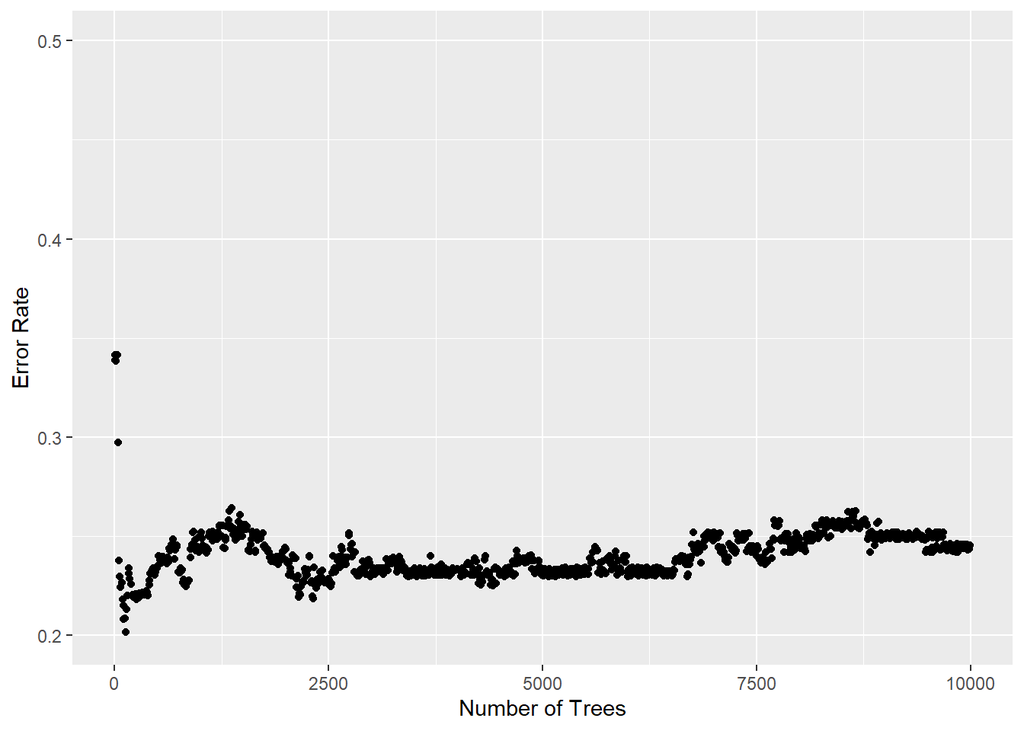

```r
boosterrror$rowname <- as.numeric(boosterrror$rowname)
ggplot(data = boosterrror, aes(x=rowname, y=boost.err))+
geom_jitter()+
ylim(0.2,0.5)+
xlab("Number of Trees")+
ylab("Error Rate")
```

As expected, error drops quickly as the number or tree increases to a reasonable number, and then worsens as the the number of trees increases due to overfitting, before reaching an asymptote.